# Factors Affecting Student Math Performance

Tristan Ramirez

##Introduction #Dataset Link The dataset used in this project comes from the UCI Machine Learning Repository: https://archive.ics.uci.edu/ml/datasets/student+performance

##Dataset Description This dataset contains academic and demographic information about Portuguese secondary school students. Each observation represents one student. Variables include demographic information (age, sex, address), family background (Medu, Fedu), lifestyle behaviors (studytime, Walc, internet), and academic performance (G1, G2, G3).

For this project, the math (student-mat.csv) and Portuguese (student-por.csv) datasets were merged using shared identifying variables. After merging, the final dataset contains 382 students and 53 variables.

##Motivation -To understand factors associated with secondary school success.

-How can we increase or improve chances of success.

- To see how academic performance can be influenced by many factors like study habits, alcohol consumption, parental education, and resources like the internet.

##Basic Summary Statistics

```r
library(tidyverse)
setwd("/Users/tristanramirez/Desktop/comp_things/comp_classes/Comp 162/project")

d1 = read.table("student-mat.csv", sep=";", header=TRUE)
d2 = read.table("student-por.csv", sep=";", header=TRUE)

d3 = merge(d1, d2, by=c("school","sex","age","address","famsize","Pstatus","Medu","Fedu","Mjob","Fjob","reason","nursery","internet"))

#nrow(d3)
#str(d3)
#summary(d3)
```

Number of observations: 382 Number of variables: 53

##Visualizations ##Quantitative vs Quantitative: Study Time and Final Math Grade

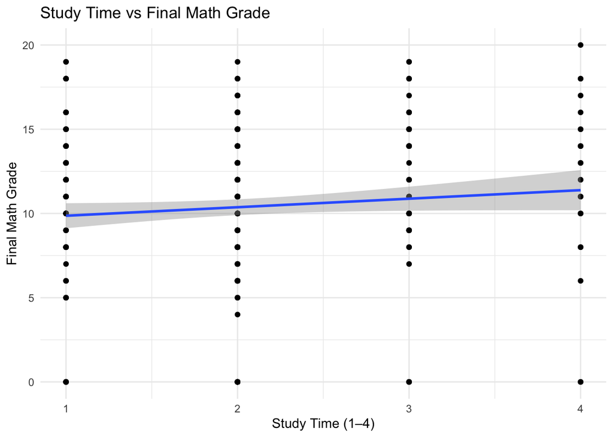

```r
ggplot(d3, aes(x = studytime.x, y = G3.x)) +
  geom_point() +
  geom_smooth(method = "lm") +
  labs(
    title = "Study Time vs Final Math Grade",
    x = "Study Time (1–4)",
    y = "Final Math Grade"
  ) +
  theme_minimal()
```

Interpretation:

##Categorical vs Quantitative: Alcohol Consumption and Final Math Grade

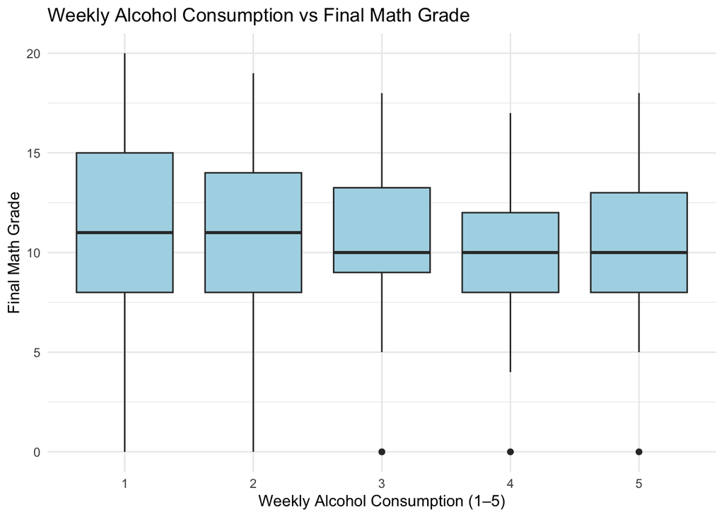

```r
ggplot(d3, aes(x = factor(Walc.x), y = G3.x)) +
  geom_boxplot(fill = "lightblue") +
  labs(
    title = "Weekly Alcohol Consumption vs Final Math Grade",
    x = "Weekly Alcohol Consumption (1–5)",
    y = "Final Math Grade"
  ) +
  theme_minimal()
```

##Dataset Manipulation

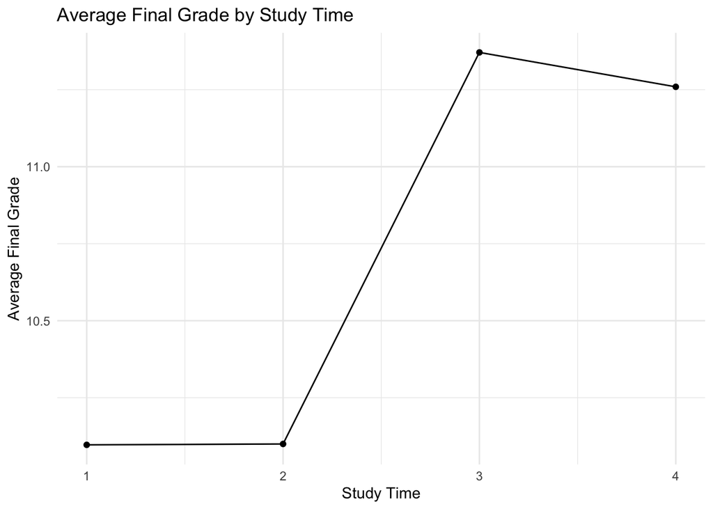

```r
d3 <- d3 %>%
  mutate(Avg_grade_math = (G1.x + G2.x + G3.x)/3)

d3 %>%
  group_by(studytime.x) %>%
  summarize(mean_G3 = mean(G3.x)) %>%
  ggplot(aes(studytime.x, mean_G3)) +
  geom_point() +
  geom_line() +
  labs(
    title = "Average Final Grade by Study Time",
    x = "Study Time",
    y = "Average Final Grade"
  ) +
  theme_minimal()
```

Interpretation:

##Statistical Analyses Correlation: Study Time and Final Math Grade

```r
cor.test(d3$studytime.x, d3$G3.x)
```

```
##
##  Pearson's product-moment correlation
##
## data:  d3$studytime.x and d3$G3.x
## t = 1.788, df = 380, p-value = 0.07457
## alternative hypothesis: true correlation is not equal to 0
## 95 percent confidence interval:
##  -0.009082369  0.189935790
## sample estimates:
##        cor
## 0.09133868
```

Interpretation:

The correlation between study time and final math grade is positive but very weak( r = 0091). Since the p-value(0.0746) is greater than 0.05, the relationship is not statistically significant. This means we do not have strong evidence that study time is linearly associated with final math grade in the larger population.

Correlation: Past Class Failures and Final Math Grade

```r
cor.test(d3$failures.x, d3$G3.x)
```

```
##
##  Pearson's product-moment correlation
##
## data:  d3$failures.x and d3$G3.x
## t = -8.0266, df = 380, p-value = 1.264e-14
## alternative hypothesis: true correlation is not equal to 0
## 95 percent confidence interval:
##  -0.4633770 -0.2915413
## sample estimates:
##        cor
## -0.3807415
```

Interpretation:

There is a moderate negative correlation between past failures and final math grade (r = -0.381), meaning students with more previous failures tend to earn lower final grades. The relationship is highly statistically significant (p = 1.264e-14), This shows us a negative association in the population. It shows that past academic failure is an important predictor of lower academic performance.

Linear Regression: Predicting Final Grade from Study Time

```r
model1 <- lm(G3.x ~ studytime.x, data = d3)
summary(model1)
```

```
##
## Call:
## lm(formula = G3.x ~ studytime.x, data = d3)
##
## Residuals:
##     Min      1Q  Median      3Q     Max
## -11.383  -1.876   0.136   3.136   9.136
##
## Coefficients:
##             Estimate Std. Error t value Pr(>|t|)
## (Intercept)   9.3578     0.6235  15.008   <2e-16 ***
## studytime.x   0.5062     0.2831   1.788   0.0746 .
## ---
## Signif. codes:  0 '***' 0.001 '**' 0.01 '*' 0.05 '.' 0.1 ' ' 1
##
## Residual standard error: 4.674 on 380 degrees of freedom
## Multiple R-squared:  0.008343,   Adjusted R-squared:  0.005733
## F-statistic: 3.197 on 1 and 380 DF,  p-value: 0.07457
```

Interpretation:

The regression results show that study time has a small positive effect on final math grade. The slope coefficient (0.5062) means that for each one-unit increase in study time, the final grade increases by about 0.51 points on average. However, the p-value (0.0746) is greater than 0.05, so the relationship is not statistically significant at the 5% level. Additionally, the R² value (0.0083) is very low, meaning study time explains less than 1% of the variation in final grades. Overall, there is weak evidence that study time predicts final math grade in the larger population.

T-Test: Internet Access and Final Math Grade

```r
t.test(G3.x ~ internet, data = d3)
```

```
##
##  Welch Two Sample t-test
##
## data:  G3.x by internet
## t = -1.7644, df = 80.452, p-value = 0.08146
## alternative hypothesis: true difference in means between group no and group yes is not equal to 0
## 95 percent confidence interval:
##  -2.4425587  0.1466881
## sample estimates:
##  mean in group no mean in group yes
##          9.413793         10.561728
```

Interpretation:

The average final math grade for students without internet access is 9.41, while the average for students with internet access is 10.56. Although students with internet access have a higher mean grade, the p-value (0.0815) is greater than 0.05, meaning the difference is not statistically significant at the 5% level. Additionally, the 95% confidence interval includes 0, which further suggests that we do not have strong evidence of a true difference in final math grades between students with and without internet access in the larger population.

Conclusion:

This analysis examined several factors that may influence student math performance using the Student Performance dataset. While study time showed a small positive relationship with final math grade, the correlation and regression results were not statistically significant at the 5% level. This suggests that study time alone is not a strong predictor of final performance.